# Lab 2: Summarizing Multivariate Data

Reesa Johninsta

## Reading the Data

In this lab, we will examine data college tuition rates, based on a 1995 dataset from US News and World Report.

```r
# Read Data
colleges = read.csv('http://kbodwin.web.unc.edu/files/2016/09/tuition_final.csv')

# Adjust labels for later

colleges <- colleges %>% mutate(
  Name = gsub("California State Univ. at", "CSU", Name),
  Name = gsub("California State University at", "CSU", Name),
  Name = gsub("California Polytechnic", "Cal Poly", Name),
  Name = gsub("California Poly", "Cal Poly", Name),
  Name = gsub("University of California at", "UC", Name)
)
```

Check out the `summary()` of the dataset and familiarize yourself with the variables.

```r
summary(colleges)
```

```
##        ID            Name               State         Public
##  Min.   : 1002   Length:1302        NY     :101   Min.   :1.00
##  1st Qu.: 1874   Class :character   PA     : 83   1st Qu.:1.00
##  Median : 2650   Mode  :character   CA     : 70   Median :2.00
##  Mean   : 3126                      TX     : 60   Mean   :1.64
##  3rd Qu.: 3431                      MA     : 56   3rd Qu.:2.00
##  Max.   :30431                      OH     : 52   Max.   :2.00
##                                     (Other):880
##     Avg.SAT        Avg.ACT       Applied         Accepted
##  Min.   : 600   Min.   :11    Min.   :   35   Min.   :   35
##  1st Qu.: 884   1st Qu.:20    1st Qu.:  696   1st Qu.:  554
##  Median : 957   Median :22    Median : 1470   Median : 1095
##  Mean   : 968   Mean   :22    Mean   : 2752   Mean   : 1871
##  3rd Qu.:1038   3rd Qu.:24    3rd Qu.: 3314   3rd Qu.: 2303
##  Max.   :1410   Max.   :31    Max.   :48094   Max.   :26330
##  NA's   :523    NA's   :588   NA's   :10      NA's   :11
##       Size        Out.Tuition       Spending
##  Min.   :   59   Min.   : 1044   Min.   : 1834
##  1st Qu.:  966   1st Qu.: 6111   1st Qu.: 6116
##  Median : 1812   Median : 8670   Median : 7729
##  Mean   : 3693   Mean   : 9277   Mean   : 8988
##  3rd Qu.: 4540   3rd Qu.:11659   3rd Qu.:10054
##  Max.   :31643   Max.   :25750   Max.   :62469
##  NA's   :3       NA's   :20      NA's   :39
```

```r
skim(colleges)
```

```
## Skim summary statistics
##  n obs: 1302
##  n variables: 11
##
## -- Variable type:character ---------------------------------------------------------------
##  variable missing complete    n min max empty n_unique
##      Name       0     1302 1302   8  45     0     1274
##
## -- Variable type:factor ------------------------------------------------------------------
##  variable missing complete    n n_unique                      top_counts
##     State       0     1302 1302       51 NY: 101, PA: 83, CA: 70, TX: 60
##  ordered
##    FALSE
##
## -- Variable type:integer -----------------------------------------------------------------
##     variable missing complete    n    mean      sd   p0     p25    p50
##     Accepted      11     1291 1302 1870.68 2250.87   35  554.5  1095
##      Applied      10     1292 1302 2752.1  3541.97   35  695.75 1470
##      Avg.ACT     588      714 1302   22.12    2.58   11   20.25   22
##      Avg.SAT     523      779 1302  967.98  123.58  600  884.5   957
##           ID       0     1302 1302 3126.37 2970.17 1002 1874.5  2649.5
##  Out.Tuition      20     1282 1302 9276.91 4170.77 1044 6111    8670
##       Public       0     1302 1302    1.64    0.48    1    1       2
##         Size       3     1299 1302 3692.67 4544.85   59  966    1812
##     Spending      39     1263 1302 8987.89 5347.46 1834 6115.5  7729
##       p75  p100     hist
##   2303    26330 ▇▁▁▁▁▁▁▁
##   3314.25 48094 ▇▁▁▁▁▁▁▁
##     24       31 ▁▁▁▇▇▅▁▁
##   1038     1410 ▁▁▆▇▅▂▁▁
##   3430.75 30431 ▇▁▁▁▁▁▁▁
##  11659    25750 ▂▇▇▅▂▂▁▁
##      2        2 ▅▁▁▁▁▁▁▇
##   4539.5  31643 ▇▂▁▁▁▁▁▁
##  10054    62469 ▇▃▁▁▁▁▁▁
```

- Briefly describe the variables in this dataset - what do they represent? What are the possible values?

ID is the ID# of the college, Names are the name of college, State is where the college is located, Public is if it is public or not, Avg.SAT and Avg.ACT is the average ACT and SATs, Applied is number of people applied, Accepted is number of people accepted. Size is size of college, Out.Tutiton is out of state tuition, and Spending is how much the school spends. *** ## Adjusting and cleaning the data

Note that the variable “Public” tells us whether a school is public or private. However, the categories are labeled “1” and “2”, so R thinks this is a numerical value. We will use the dplyr function `mutate()` to adjust this variable, and also to create a new one called `Acc.Rate`.

```r
colleges <- colleges %>%
  mutate(
    Public = factor(Public, labels = c("Public", "Private")),
    Acc.Rate = Accepted/Applied
  )
```

- What information is now contained in the variable Acc.Rate? Why might we prefer this to the original data?

It tells us the percentage of people that applied that got accepted. We might prefer it since it shows how selective a school which standardizes it more.

- What would happen if we removed “colleges <-” from the beginning of the above code?

It wouldn’t update the colleges data frame.

Now we would like to take a look at the public schools in California, and compare them using our multivariate plotting tools. First, let’s make a dataset containing only these schools using the dplyr function `filter()`.

```r
# Dataset of only CA public schools
CA_public <- colleges %>%
  filter(State == "CA", Public == "Public") %>%
  select(Name, Avg.SAT, Acc.Rate, Size, Out.Tuition, Spending) %>%
  na.omit()
```

- What did we do in the third line of code, using “select()”?

We only selected the data we wanted to know about for viewing:the school’s name, average SAT score, it’s acceptance rate, the size of the college,it’s out of state tuition, and the school’s spending

- What did “na.omit()” do in the fourth line of code? We omitted rows that contained NAs in any of the selected variables

## Face Plots

Now we can make plots for the CA public schools for which we have full information. We will start with the Chernoff faces plotting style.

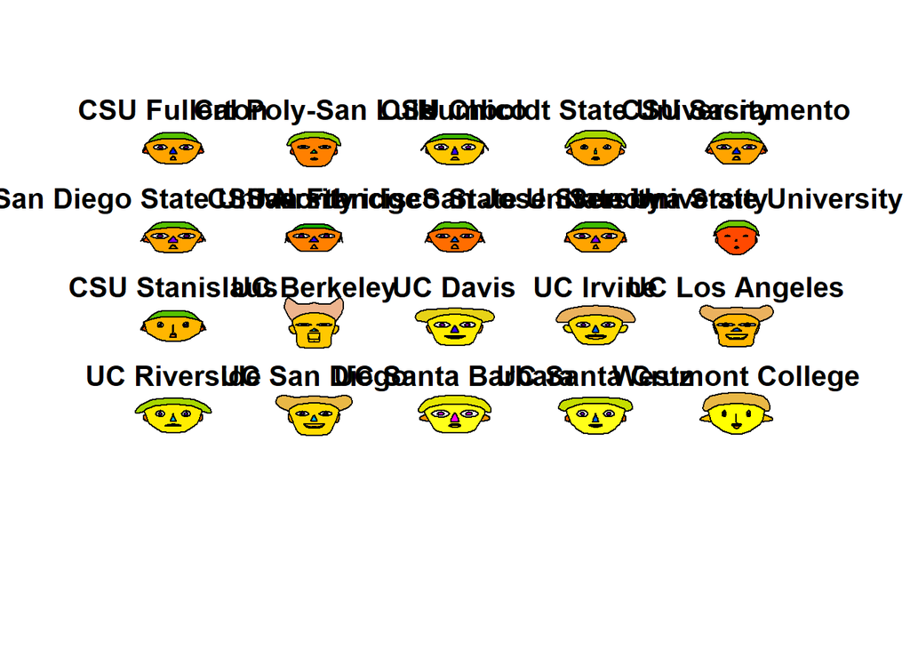

```
## effect of variables:
##  modified item       Var
##  "height of face   " "Avg.SAT"
##  "width of face    " "Acc.Rate"
##  "structure of face" "Size"
##  "height of mouth  " "Out.Tuition"
##  "width of mouth   " "Spending"
##  "smiling          " "Avg.SAT"
##  "height of eyes   " "Acc.Rate"
##  "width of eyes    " "Size"
##  "height of hair   " "Out.Tuition"
##  "width of hair   "  "Spending"
##  "style of hair   "  "Avg.SAT"
##  "height of nose  "  "Acc.Rate"
##  "width of nose   "  "Size"
##  "width of ear    "  "Out.Tuition"
##  "height of ear   "  "Spending"
```

```r
CA_public %>%
  select(Avg.SAT, Acc.Rate, Size, Out.Tuition, Spending) %>%
  faces(labels = CA_public$Name)
```

- What do you observe from this plot? Which schools are similar to each other? Which schools stand out as unique? The UCs resemble each other save UCSD, UCLA, and UCB but they seem similar to each other in color and face shape and most of he CSUs seem to resemble at least one of the other CSUs. Sonoma State University seems to stand out the most. Westmont College seems to be be very odd in face shape.
- What are the advantages and disadvantages of the face plot style? Face plots display more variables on a 2d plot, but it’s hard to interpret the results.

## Star plots

One downside of the face plots is that it is difficult to tell which specific variables are being compared. A solution to this is called “star plots”.

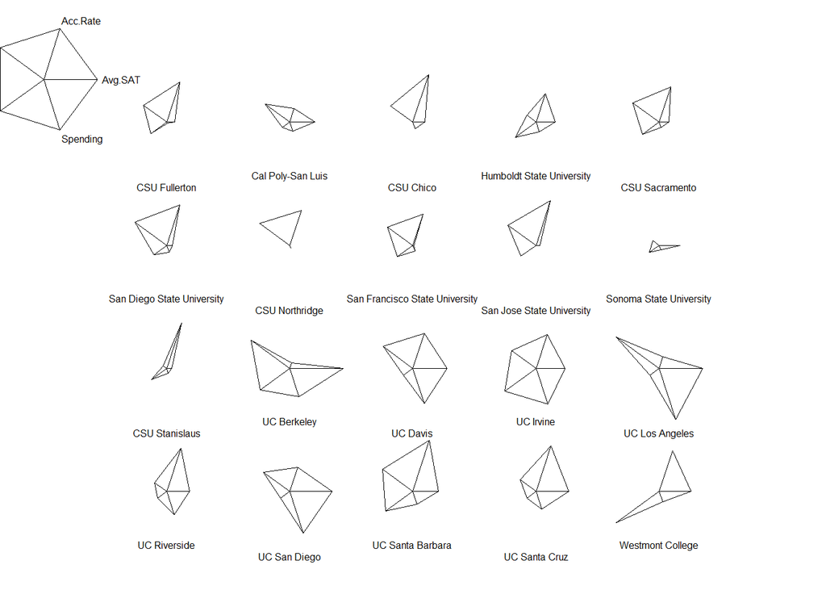

```r
CA_public %>%
  select(Avg.SAT, Acc.Rate, Size, Out.Tuition, Spending) %>%
  stars(labels = CA_public$Name, nrow = 4, key.loc = c(0,10), cex = .5)
```

- Which school has the highest out-of-state tuition in this data? Westmont college seems to be quite pricey for out of state tuition.
- Which school has the lowest acceptance rate in this data? Either Sonoma State University or UC Berkeley.
- Which two schools seem most similar to you, based on these plots? CSU FUllerton and SJSU have a similar shape for all 5 variables and are of similar size
- What are the advantages and disadvantages of this plot style? You can effectively plot multiple variables on a 2d plot and know which variables are what, but it’s hard to read if there are too many variables and can give the wrong interpretation of certain variables if a low variable is next to an average variable. *** ## Segmented Star Plots

To better visualize our data, we can “segment” our star plots, and plot them as slices of a circular area rather than as lines in a polygon.

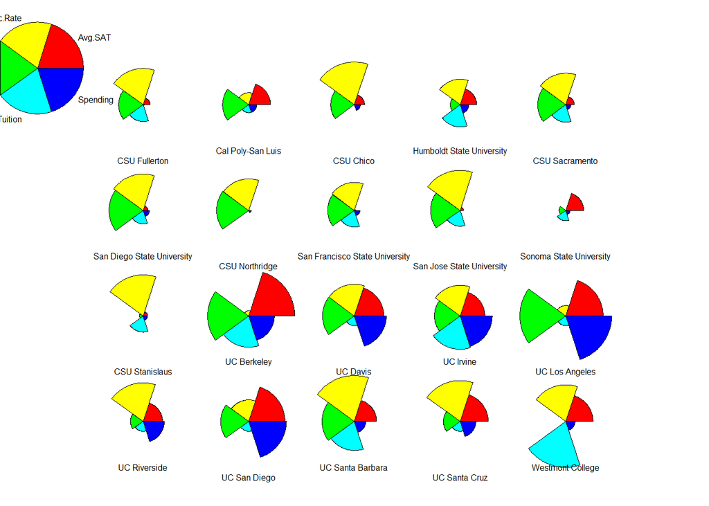

```r
CA_public %>%
  select(Avg.SAT, Acc.Rate, Size, Out.Tuition, Spending) %>%
  stars(labels = CA_public$Name, nrow = 4, key.loc = c(0,10), cex = .5, draw.segments = TRUE, col.segments = rainbow(6))
```

- In what way does Cal Poly most differ from the other CSUs? Our acceptance rate is lower, and average SAT is higher.
- In what way does Westmont College most differ from the other schools? Their out of state tuition is by far the largest.
- Which is the largest public school in California? UCLA looks to be the largest of the public
- What are the advantages and disadvantages of this plot style? It’s a lot more distinct between variables and the shape for each variable is maintained. However if the variables value is too tiny we can’t see and if there is something large next to something small, it is misleading. *** ## Scatterplots

Finally, we can think about pairwise relationships between variables, rather than comparisons between schools. We will use the `ggplot2` framework for these plots. Make sure that you understand each step in the code below:

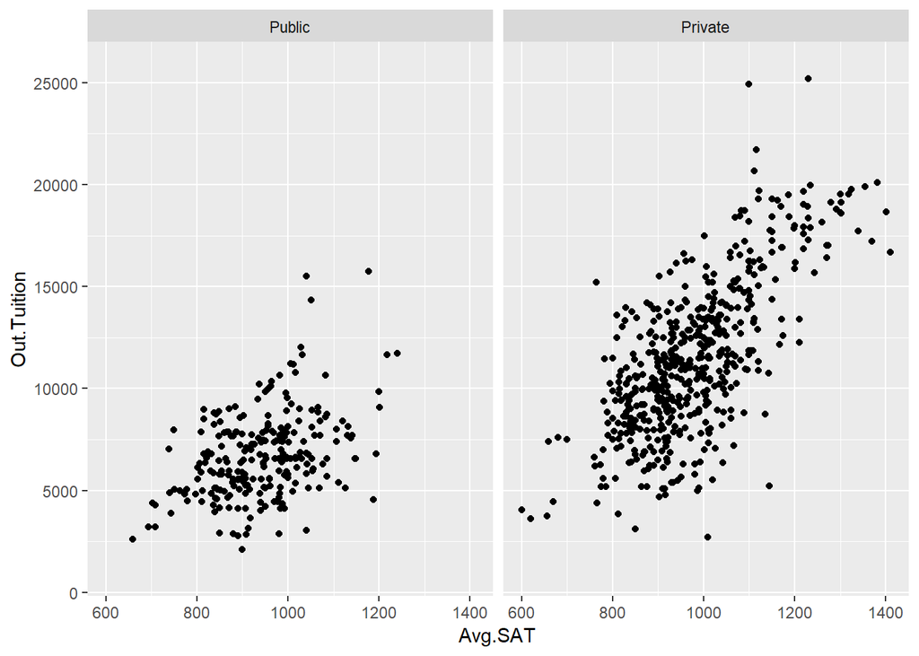

```r
colleges %>%
  ggplot(aes(x = Avg.SAT, y = Out.Tuition)) + geom_point() + facet_grid(~Public)
```

- Based on these scatterplots, is there a relationship between Average SAT score and the out-of-state tuition of a school? The points trends up for both charts, so higher SAT seems to be associated with a higher tuition.
- Based on these scatterplots, is the relationship different for Public versus Private schools? For the part of SAT scores that both plots have, the relationship seems about the same.

We can also quite easily make all the possible scatterplots for the dataset using the `ggplot` function `ggpairs`:

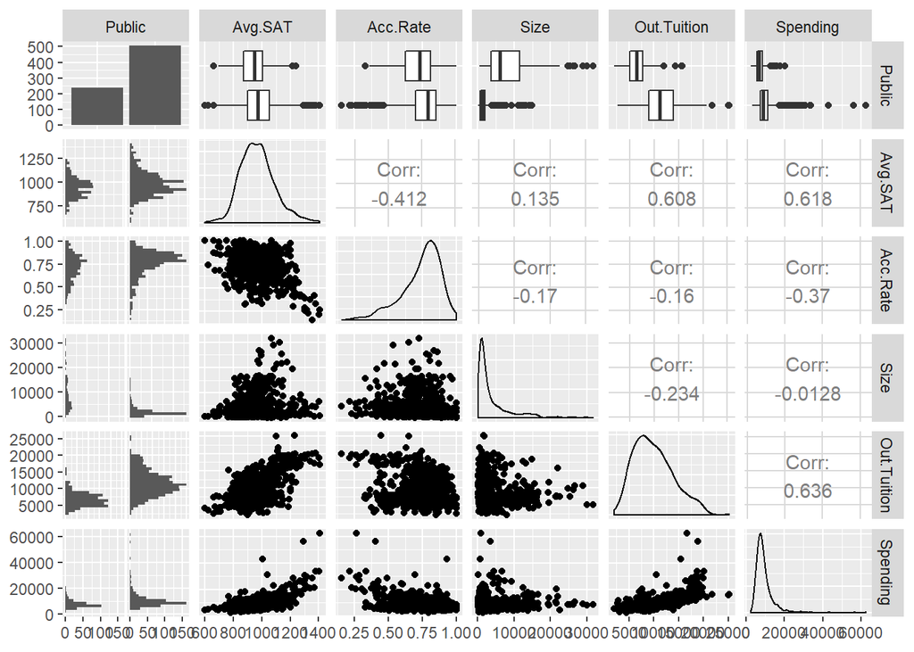

```r
colleges %>%
  select(Public, Avg.SAT, Acc.Rate, Size, Out.Tuition, Spending) %>%
  na.omit() %>%
  ggpairs()
```

- Are there more public schools or more private schools in this dataset? There are more private schools.
- Which variables are very different between public schools and private schools? Does this surprise you? Out of state tuition is cheaper for public schools, and public schools tend to have larger sizes
- Which variables seem to be strongly positively correlated? In real world terms, why does this make sense? Spending and Out of state tuition seems to be more strongly positivelt correlated, which makes sense since more money in tuition means more money to spend. Average SAT are also highly correlated to high out of state tuition and school spending, since people with high SAT scores probably could afford tutoring to get those scores.
- Which variables seem to be strongly negatively correlated? In real world terms, why does this make sense? Acceptance rate is relatively negatively correlated to average SAT (more selective schools can get more smarter kids), and if they are more selective, they can usually charge higher tuition which is why acceptance rate is relatively negatively correlated to average SAT.
- Which variables, if any, seem like they might be Normally distributed? Average SAT